# Sampling

El Mex

```r
library(tidyverse)
library(moderndive)
```

# Sampling

## Sampling bowl activity

### What proportion of this bowl’s balls are red?

**After finishing the getting-several-samples experiment, we saved our 33 groups of friends’ results in the `tactile_prop_red` data frame included in the `moderndive` package. Run the following to display the first 10 of 33 rows:**

```r
head(tactile_prop_red, 10)
```

```
## # A tibble: 10 x 4
##    group            replicate red_balls prop_red
##    <chr>                <int>     <int>    <dbl>
##  1 Ilyas, Yohan             1        21     0.42
##  2 Morgan, Terrance         2        17     0.34
##  3 Martin, Thomas           3        21     0.42
##  4 Clark, Frank             4        21     0.42
##  5 Riddhi, Karina           5        18     0.36
##  6 Andrew, Tyler            6        19     0.38
##  7 Julia                    7        19     0.38
##  8 Rachel, Lauren           8        11     0.22
##  9 Daniel, Caroline         9        15     0.3
## 10 Josh, Maeve             10        17     0.34
```

**Let’s visualize the distribution of these 33 proportions using `geom_histogram()` with `binwidth = 0.05`. Note that setting `boundary = 0.4` indicates that we want a binning scheme such that one of the bins’ boundary is at 0.4**

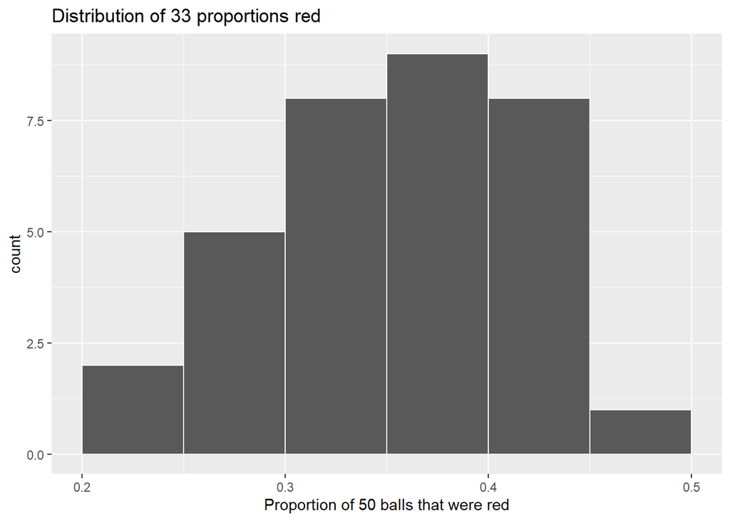

```r
ggplot(tactile_prop_red, aes(x = prop_red)) +
  geom_histogram(binwidth = 0.05, boundary = 0.4, color = "white") +
  labs(x = "Proportion of 50 balls that were red",
       title = "Distribution of 33 proportions red")
```

## Virtual sampling

### Using the virtual shovel once

**Explore the data frame named `bowl` in the `moderndive` package**

```r
glimpse(bowl, 10)
```

```
## Rows: 2,400
## Columns: 2
## $ ball_ID <int> ...
## $ color   <chr> ...
```

```r
head(bowl, 10)
```

```
## # A tibble: 10 x 2
##    ball_ID color
##      <int> <chr>
##  1       1 white
##  2       2 white
##  3       3 white
##  4       4 red
##  5       5 white
##  6       6 white
##  7       7 red
##  8       8 white
##  9       9 red
## 10      10 white
```

**It has 2400 rows, telling us that the bowl contains 2400 equally sized balls, white and red. Now we’re going to use the `rep_sample_n()` function included in the `moderndive` package. This function allows us to take `rep`eated, or `rep`licated, `samples` of size `n`**

```r
# assign the result to "virtual_shovel"
virtual_shovel <- bowl %>%
  rep_sample_n(size = 50)

virtual_shovel
```

```
## # A tibble: 50 x 3
## # Groups:   replicate [1]
##    replicate ball_ID color
##        <int>   <int> <chr>
##  1         1    1390 red
##  2         1    1413 white
##  3         1    2013 white
##  4         1    1930 white
##  5         1    1503 white
##  6         1     116 white
##  7         1     816 red
##  8         1     176 white
##  9         1    1562 red
## 10         1     138 red
## # ... with 40 more rows
```

**What does the replicate variable indicate? In `virtual_shovel`’s case, `replicate` is equal to 1 for all 50 rows. This is telling us that these 50 rows correspond to the first repeated/replicated use of the shovel, in our case our first sample**

**For each of our 50 sampled balls, let’s identify if it is red or not using a test for equality with `==`. Let’s create a new Boolean variable `is_red` using the `mutate()` function**

```r
virtual_shovel %>%
  mutate(is_red = (color == "red"))
```

```
## # A tibble: 50 x 4
## # Groups:   replicate [1]
##    replicate ball_ID color is_red
##        <int>   <int> <chr> <lgl>
##  1         1    1390 red   TRUE
##  2         1    1413 white FALSE
##  3         1    2013 white FALSE
##  4         1    1930 white FALSE
##  5         1    1503 white FALSE
##  6         1     116 white FALSE
##  7         1     816 red   TRUE
##  8         1     176 white FALSE
##  9         1    1562 red   TRUE
## 10         1     138 red   TRUE
## # ... with 40 more rows
```

**Let’s compute the number of balls out of 50 that are red using the `summarize()` function**

```r
virtual_shovel %>%
  mutate(is_red = (color == "red")) %>%
  summarize(num_red = sum(is_red))
```

```
## # A tibble: 1 x 2
##   replicate num_red
##       <int>   <int>
## 1         1      21
```

**Finally, let’s compute the proportion of the 50 sampled balls that are red by dividing `num_red` by 50:**

```r
virtual_shovel %>%
  mutate(is_red = color == "red") %>%
  summarize(num_red = sum(is_red)) %>%
  mutate(prop_red = num_red / 50)
```

```
## # A tibble: 1 x 3
##   replicate num_red prop_red
##       <int>   <int>    <dbl>
## 1         1      21     0.42
```

```r
virtual_shovel %>%
  summarize(num_red = sum(color == "red")) %>%
  mutate(prop_red = num_red / 50)
```

```
## # A tibble: 1 x 3
##   replicate num_red prop_red
##       <int>   <int>    <dbl>
## 1         1      21     0.42
```

### Using the virtual shovel 33 times

**Remember we had 33 groups of students each use the shovel, yielding 33 samples of size 50 balls. We can perform this repeated/replicated sampling virtually by once again using our virtual shovel function `rep_sample_n()`, but by adding the `reps = 33` argument**

```r
virtual_samples <- bowl %>%
  rep_sample_n(size = 50, reps = 33)

glimpse(virtual_samples)
```

```
## Rows: 1,650
## Columns: 3
## Groups: replicate [33]
## $ replicate <int> 1, 1, 1, 1, 1, 1, 1, 1, 1, 1, 1, 1, 1, 1, 1, 1, 1, 1, 1, ...
## $ ball_ID   <int> 1517, 1241, 600, 2383, 2146, 2294, 2098, 1591, 2290, 1640...
## $ color     <chr> "white", "white", "white", "red", "white", "red", "red", ...
```

```r
head(virtual_samples, 10)
```

```
## # A tibble: 10 x 3
## # Groups:   replicate [1]
##    replicate ball_ID color
##        <int>   <int> <chr>
##  1         1    1517 white
##  2         1    1241 white
##  3         1     600 white
##  4         1    2383 red
##  5         1    2146 white
##  6         1    2294 red
##  7         1    2098 red
##  8         1    1591 white
##  9         1    2290 white
## 10         1    1640 white
```

**Let’s now take `virtual_samples` and compute the resulting 33 proportions red by using additionally `group_by()` of the `replicate` variable**

```r
# assign the result to a variable called "virtual_prop_red"
virtual_prop_red <- virtual_samples %>%
  group_by(replicate) %>%
  summarize(red = sum(color == "red")) %>%
  mutate(prop_red = red / 50)

virtual_prop_red
```

```
## # A tibble: 33 x 3
##    replicate   red prop_red
##        <int> <int>    <dbl>
##  1         1    17     0.34
##  2         2    13     0.26
##  3         3    15     0.3
##  4         4    24     0.48
##  5         5    20     0.4
##  6         6    19     0.38
##  7         7    25     0.5
##  8         8    15     0.3
##  9         9    21     0.42
## 10        10    16     0.32
## # ... with 23 more rows
```

**Let’s visualize this variation in a histogram in Figure 7.8. Note that we add `binwidth = 0.05` and `boundary = 0.4` arguments as well**

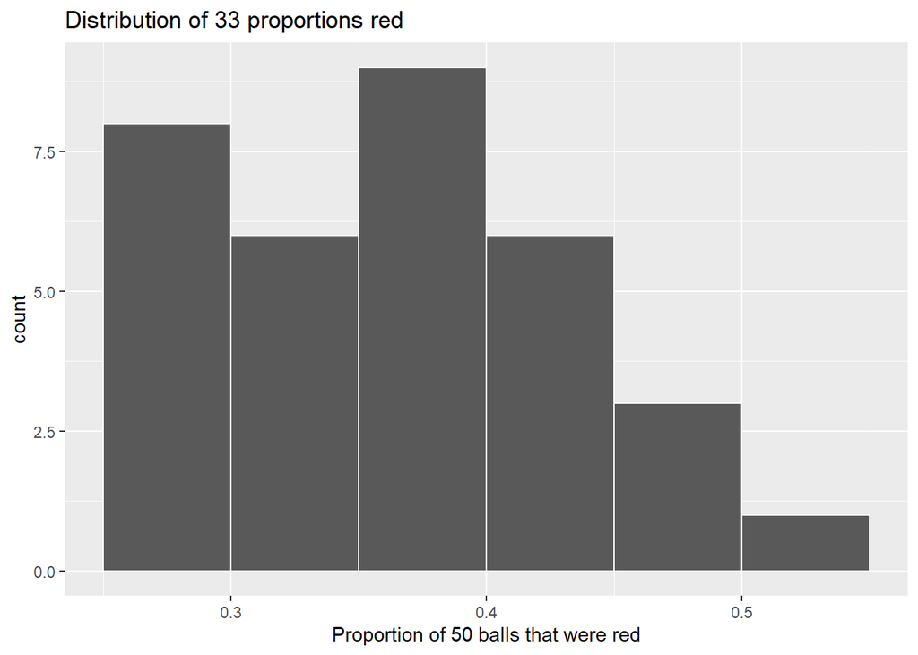

```r
ggplot(virtual_prop_red, aes(x = prop_red)) +
  geom_histogram(binwidth = 0.05, boundary = 0.4, color = "white") +
  labs(x = "Proportion of 50 balls that were red",
       title = "Distribution of 33 proportions red")
```

**The most frequently occurring proportions were between 35% and 40%. Why do we have these differences in proportions red? Because of sampling variation**

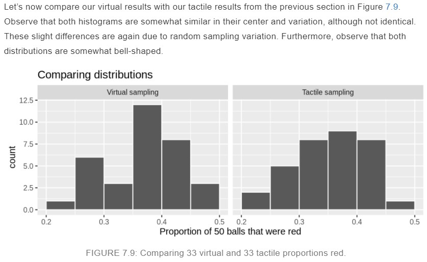

### Using the virtual shovel 1000 times

**Let’s once again use the `rep_sample_n()` function with sample `size` set to be 50 once again, but this time with the number of replicates `reps` set to `1000`**

```r
virtual_samples <- bowl %>%
  rep_sample_n(size = 50, reps = 1000)

glimpse(virtual_samples)
```

```
## Rows: 50,000
## Columns: 3
## Groups: replicate [1,000]
## $ replicate <int> 1, 1, 1, 1, 1, 1, 1, 1, 1, 1, 1, 1, 1, 1, 1, 1, 1, 1, 1, ...
## $ ball_ID   <int> 1281, 1982, 520, 1486, 774, 335, 32, 2149, 250, 1569, 165...
## $ color     <chr> "red", "red", "white", "white", "white", "white", "red", ...
```

```r
head(virtual_samples, 10)
```

```
## # A tibble: 10 x 3
## # Groups:   replicate [1]
##    replicate ball_ID color
##        <int>   <int> <chr>
##  1         1    1281 red
##  2         1    1982 red
##  3         1     520 white
##  4         1    1486 white
##  5         1     774 white
##  6         1     335 white
##  7         1      32 red
##  8         1    2149 white
##  9         1     250 red
## 10         1    1569 white
```

**Compute the resulting 1000 proportions of red balls**

```r
virtual_prop_red <- virtual_samples %>%
  group_by(replicate) %>%
  summarize(red = sum(color == "red")) %>%
  mutate(prop_red = red / 50)

head(virtual_prop_red, 10)
```

```
## # A tibble: 10 x 3
##    replicate   red prop_red
##        <int> <int>    <dbl>
##  1         1    16     0.32
##  2         2    19     0.38
##  3         3    24     0.48
##  4         4    12     0.24
##  5         5    18     0.36
##  6         6    18     0.36
##  7         7    14     0.28
##  8         8    12     0.24
##  9         9    17     0.34
## 10        10    13     0.26
```

**Let’s now visualize the distribution of these 1000 replicates of `prop_red` in a histogram**

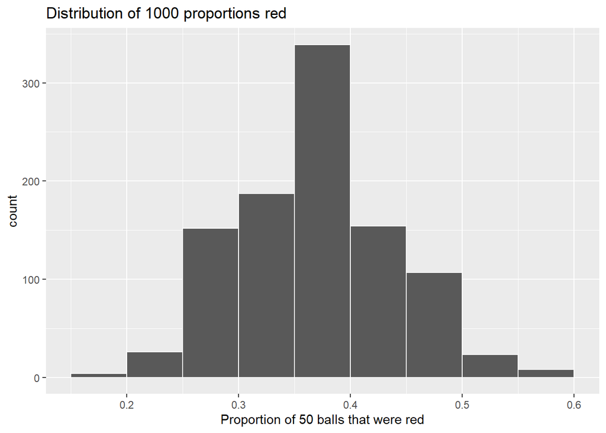

```r
ggplot(virtual_prop_red, aes(x = prop_red)) +
  geom_histogram(binwidth = 0.05, boundary = 0.4, color = "white") +
  labs(x = "Proportion of 50 balls that were red",
       title = "Distribution of 1000 proportions red")
```

### Using different shovels

**Now say instead of just one shovel, you have three choices of shovels to extract a sample of balls with: shovels of size 25, 50, and 100**

**Let’s use `rep_sample_n()` with `size` set to `25`, `50`, and `100`, respectively, while keeping the number of repeated/replicated samples at 1000:**

1. Virtually use the appropriate shovel to generate 1000 samples with size balls
2. Compute the resulting 1000 replicates of the proportion of the shovel’s balls that are red
3. Visualize the distribution of these 1000 proportions red using a histogram

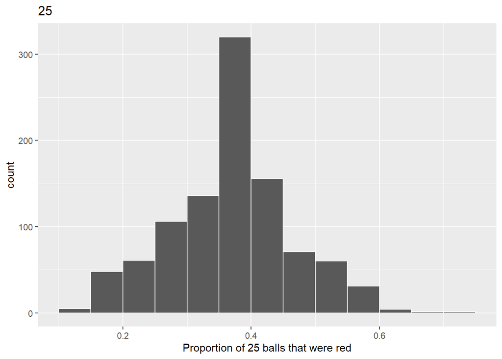

```r
# Segment 1: sample size = 25------------------------------
#  1.a) Virtually use shovel 1000 times
virtual_samples_25 <- bowl %>%
  rep_sample_n(size = 25, reps = 1000)

# 1.b) Compute resulting 1000 replicates of proportion red
virtual_prop_red_25 <- virtual_samples_25 %>%
  group_by(replicate) %>%
  summarize(red = sum(color == "red")) %>%
  mutate(prop_red = red / 25)

# 1.c) Plot distribution via a histogram
ggplot(virtual_prop_red_25, aes(x = prop_red)) +
  geom_histogram(binwidth = 0.05, boundary = 0.4, color = "white") +
  labs(x = "Proportion of 25 balls that were red",
       title = "25")
```

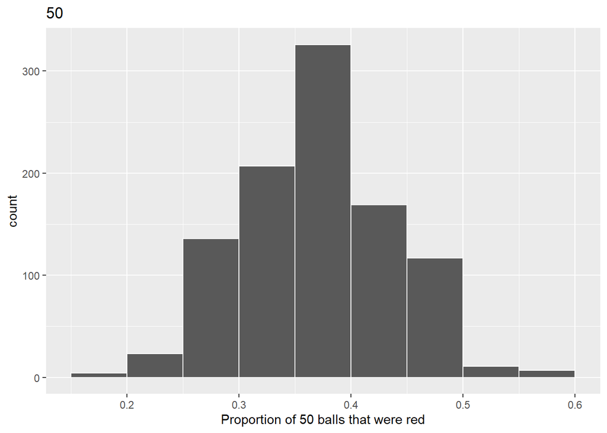

```r
# Segment 2: sample size = 50 ------------------------------
# 2.a) Virtually use shovel 1000 times
virtual_samples_50 <- bowl %>%
  rep_sample_n(size = 50, reps = 1000)

# 2.b) Compute resulting 1000 replicates of proportion red
virtual_prop_red_50 <- virtual_samples_50 %>%
  group_by(replicate) %>%
  summarize(red = sum(color == "red")) %>%
  mutate(prop_red = red / 50)

# 2.c) Plot distribution via a histogram
ggplot(virtual_prop_red_50, aes(x = prop_red)) +
  geom_histogram(binwidth = 0.05, boundary = 0.4, color = "white") +
  labs(x = "Proportion of 50 balls that were red",
       title = "50")
```

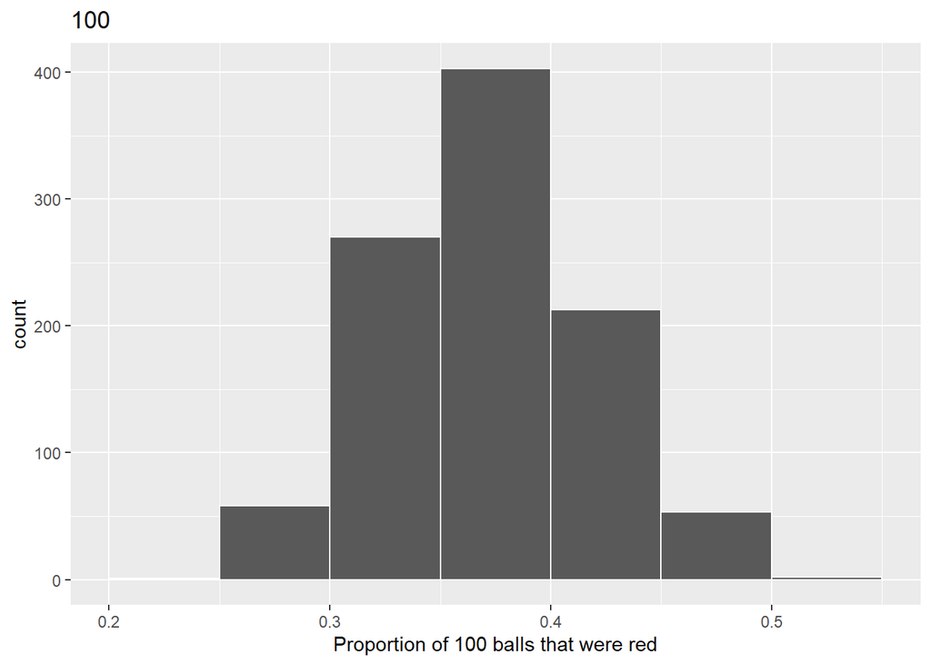

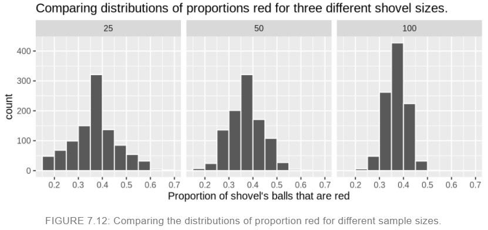

```r
# Segment 3: sample size = 100 ------------------------------
# 3.a) Virtually using shovel with 100 slots 1000 times
virtual_samples_100 <- bowl %>%
  rep_sample_n(size = 100, reps = 1000)

# 3.b) Compute resulting 1000 replicates of proportion red
virtual_prop_red_100 <- virtual_samples_100 %>%
  group_by(replicate) %>%
  summarize(red = sum(color == "red")) %>%
  mutate(prop_red = red / 100)

# 3.c) Plot distribution via a histogram
ggplot(virtual_prop_red_100, aes(x = prop_red)) +
  geom_histogram(binwidth = 0.05, boundary = 0.4, color = "white") +
  labs(x = "Proportion of 100 balls that were red",
       title = "100")
```

**Observe that as the sample size increases, the variation of the 1000 replicates of the proportion of red decreases. In other words, as the sample size increases, there are fewer differences due to sampling variation and the distribution centers more tightly around the same value. Eyeballing Figure 7.12, all three histograms appear to center around roughly 40%**

**We can be numerically explicit about the amount of variation in our three sets of 1000 values of `prop_red` using the *standard deviation*. A standard deviation is a summary statistic that measures the amount of variation within a numerical variable**

```r
# n = 25
virtual_prop_red_25 %>%
  summarize(sd = sd(prop_red))
```

```
## # A tibble: 1 x 1
##       sd
##    <dbl>
## 1 0.0959
```

```r
# n = 50
virtual_prop_red_50 %>%
  summarize(sd = sd(prop_red))
```

```
## # A tibble: 1 x 1
##       sd
##    <dbl>
## 1 0.0673
```

```r
# n = 100
virtual_prop_red_100 %>%
  summarize(sd = sd(prop_red))
```

```
## # A tibble: 1 x 1
##       sd
##    <dbl>
## 1 0.0473
```

TABLE 7.1: Comparing standard deviations of proportions red for three different shovels

[output not shown]

**As we observed in Figure 7.12 & Table 7.1, as the sample size increases, the variation decreases. In other words, there is less variation in the 1000 values of the proportion red. So as the sample size increases, our guesses at the true proportion of the bowl’s balls that are red get more precise**

**What was the value of the population proportion *p* of the *N* = 2400 balls in the actual bowl that were red? There were 900 red balls, for a proportion red of 900/2400 = 0.375 = 37.5%! How do we know this? Did the authors do an exhaustive count of all the balls? No! They were listed in the contents of the box that the bowl came in! Hence we were able to make the contents of the virtual `bowl` match the tactile bowl:**

```r
bowl %>%
  summarize(sum_red = sum(color == "red"),
            sum_not_red = sum(color != "red"))
```

```
## # A tibble: 1 x 2
##   sum_red sum_not_red
##     <int>       <int>
## 1     900        1500
```

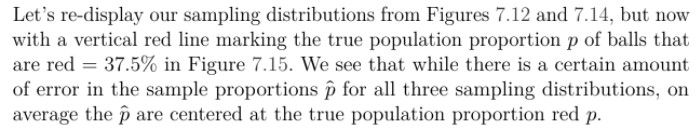

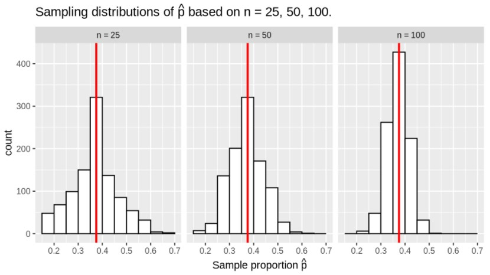

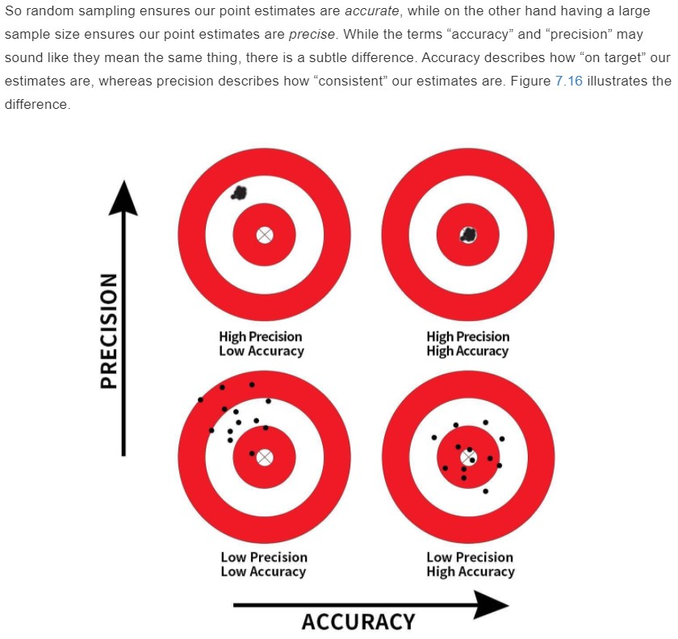

**The sampling activity involving the bowl is merely an idealized version of how sampling is done in real life. We performed this exercise only to study and understand:**

1. The effect of sampling variation.
2. The effect of sample size on sampling variation.

**This is not how sampling is done in real life. In a real-life scenario, we won’t know what the true value of the population parameter is. Furthermore, we wouldn’t take 1000 repeated/replicated samples, but rather a single sample that’s as large as we can afford.**